# Introdução ao Tidyverse

# LOG SCALES

Isso ocorreu porque a distribuicao do pib per capita abrange varias ordens de magnitude, com alguns paises na casa das dezenas de milhares de dolares e outros na casa das centenas.

Quando um de nossos eixos apresenta essa distribuição, é util trabalhar com uma escala logaritimica, ou seja, uma escala em que cada distância fixa representa uma multiplicacao do valor.

*Criando o grafico usando o log scale*

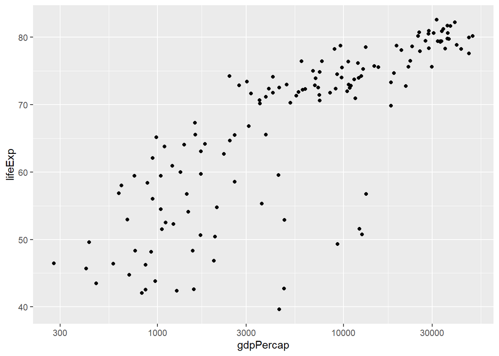

```r
ggplot(gapminder_2007, aes(x = gdpPercap, y = lifeExp)) +
  geom_point() +
    scale_x_log10()
```

Esses sao os mesmo dados, mas agora cada unidade no eixo x representa uma mudança de 10 vezes o PIB.

Nesse novo grafico podemos ver os dados de uma maneira mais linear, e podemos distinguir mais facilmente os paises na extremidade inferior do espectro.

**Algumas vezes ambos os eixos devem ser convertidos para a escala de log.

```r
# Criando o gapminder filtrado para o ano 1952
gapminder_1952 <- gapminder %>%
                  filter(year == 1952)
```

Plotando com ambos os eixos com escala de log

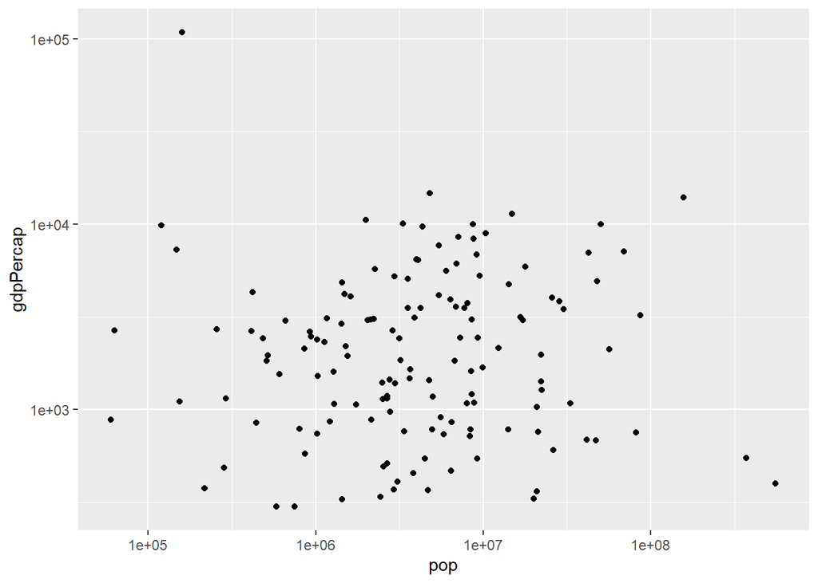

```r
ggplot (gapminder_1952, aes(x = pop, y = gdpPercap)) +
        scale_x_log10() +
        scale_y_log10() +
        geom_point()
```

# ESTÉTICA ADICIONAL - additional aesthetics

Nós aprendemos como criar uma plotagem de duas variaveis e assim enxergar sua relacao. O nosso banco de dados “gapminder” possui outras variaveis que podem também ser utilizadas, de maneira a entendermos outros relacionamentos entre elas.

Observe que continente é uma variavel categórica, e por isso apresenta valores bem especificos. Uma *boa maneira de apresentar variaveis categorias em um gráfico* é através da dimensao COLOR.

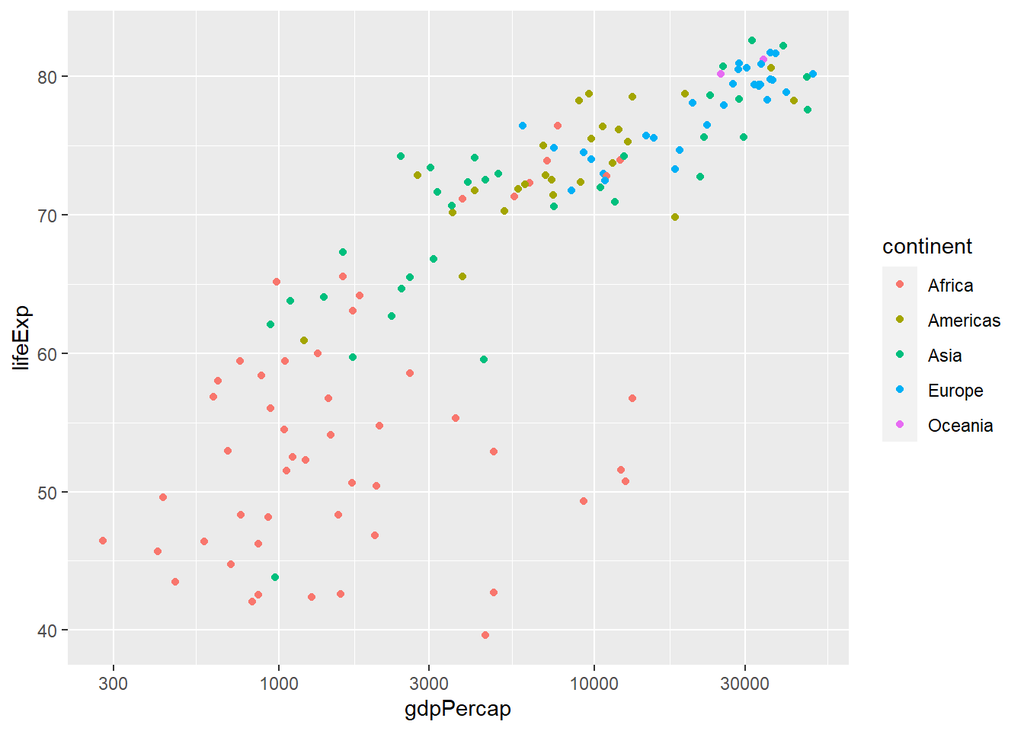

```r
ggplot (gapminder_2007, aes(x = gdpPercap, y =lifeExp, color = continent)) +
        scale_x_log10() +
        geom_point()
```

Observe que populacao (pop) é uma variavel numérica, uma *boa maneira de apresentar variaveis numericas um gráfico* é através da dimensao SIZE, que significa “tamanho”.

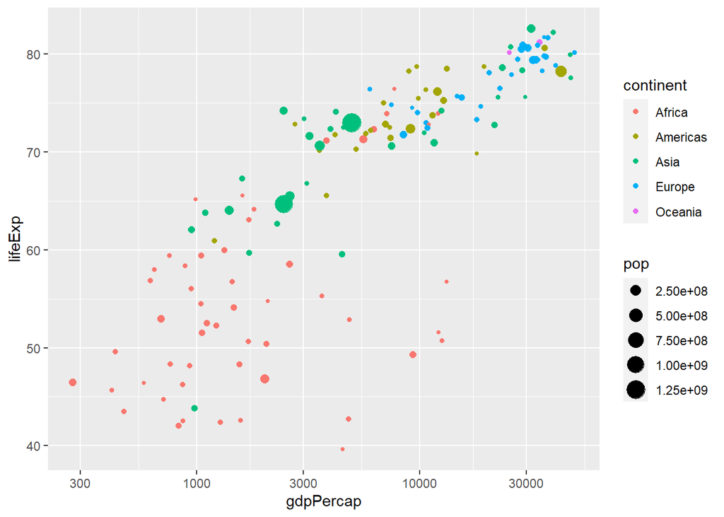

```r
ggplot (gapminder_2007, aes(x = gdpPercap, y =lifeExp, color = continent, size = pop)) +
        scale_x_log10() +
        geom_point()
```

# FACETING

Esse verbo serve para dividir nossa plotagem em subtramas para uma obter uma melhor visualizacao em um grafico menor para cada continente (por exemplo).

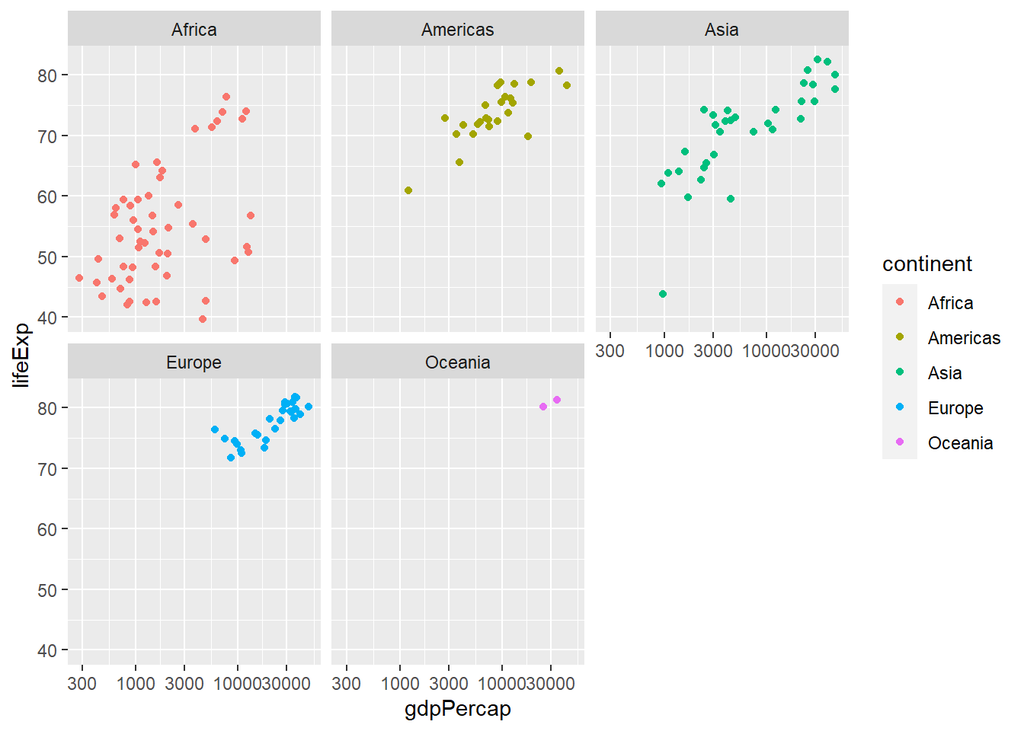

```r
ggplot (gapminder_2007, aes(x = gdpPercap, y =lifeExp, color = continent)) +
       geom_point() +
      scale_x_log10() +
      facet_wrap(~ continent)
```

```r
# ~ signica "por"
```

### CALCULO

```r
gapminder %>%
      summarize(sumPop = sum(as.numeric(pop)))
```

```
## # A tibble: 1 x 1
##        sumPop
##         <dbl>
## 1 50440465801
```

```r
gapminder_1952_2007 <- gapminder %>%
                        filter(year == 1952|2007)

# aqui eu estou pedindo os anos entre 1952 a 2007
```

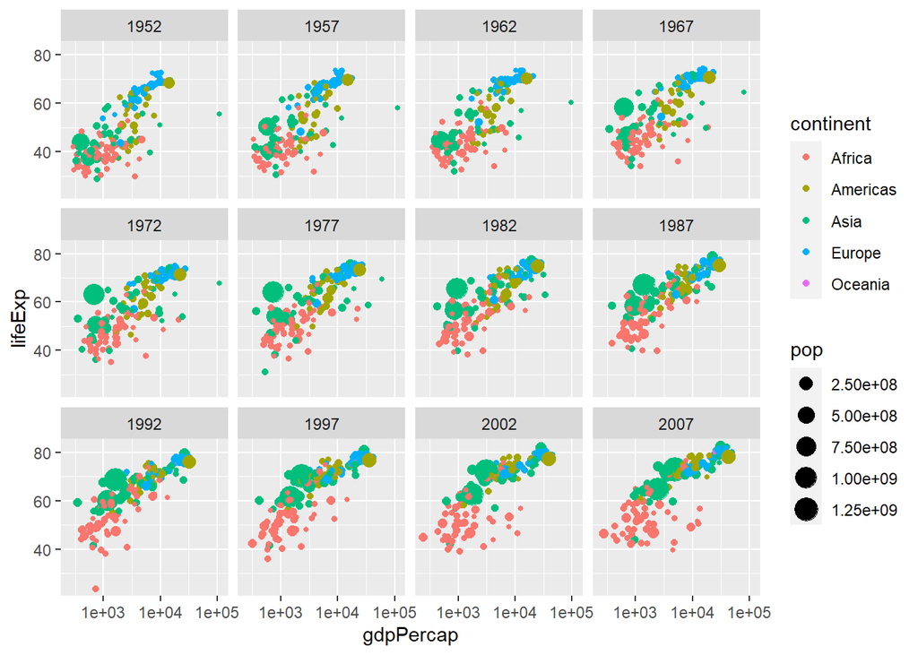

```r
ggplot(gapminder_1952_2007, aes(x = gdpPercap, y = lifeExp,
                    color = continent, size = pop)) +
          geom_point()+
          scale_x_log10()+
          facet_wrap(~year)
```

# SUMMARIZE verbo

Agora voce aprendera a resumir muitas observacoes em um unico ponto de dados .

```r
gapminder %>%
     summarize(meanLifeExp = mean(lifeExp))
```

```
## # A tibble: 1 x 1
##   meanLifeExp
##         <dbl>
## 1        59.5
```

Faz mais sentido analisar a media da expectativa de vida para um ano em especifico, por exemplo.

```r
gapminder %>%
      filter(year == 2007) %>%
     summarize(meanLifeExp = mean(lifeExp))
```

```
## # A tibble: 1 x 1
##   meanLifeExp
##         <dbl>
## 1        67.0
```

Podemos acrescentar mais detalhes a nossa funcao summarize

```r
gapminder %>%
      filter(year == 2007) %>%
      summarize(meanLifeExp = mean(lifeExp),
          totalPop = sum(as.numeric(pop)))
```

```
## # A tibble: 1 x 2
##   meanLifeExp   totalPop
##         <dbl>      <dbl>
## 1        67.0 6251013179
```

Podemos ainda summarizar via “mediana - median”, “minimo - min” e “maximo - max”

```r
gapminder %>%
        filter(year == 2007) %>%
        summarize(medianLifeExp = median(lifeExp), maxGdpPercap = max(gdpPercap))
```

```
## # A tibble: 1 x 2
##   medianLifeExp maxGdpPercap
##           <dbl>        <dbl>
## 1          71.9       49357.
```